# Practical Machine Learning Project

#### *August, 2015*

## Synopsis

Using devices such as Jawbone Up, Nike FuelBand, and Fitbit it is now possible to collect a large amount of data about personal activity relatively inexpensively. These type of devices are part of the quantified self movement – a group of enthusiasts who take measurements about themselves regularly to improve their health, to find patterns in their behavior, or because they are tech geeks. One thing that people regularly do is quantify how much of a particular activity they do, but they rarely quantify how well they do it. In this project, the goal will be to use data from accelerometers on the belt, forearm, arm, and dumbell of 6 participants. They were asked to perform barbell lifts correctly and incorrectly in 5 different ways. More information is available from the website here: http://groupware.les.inf.puc-rio.br/har (see the section on the Weight Lifting Exercise Dataset).

## Getting and Cleaning the Data

#### Load the required libraries and the data

```r
setwd("G:/Xavier/Estudios/Online/Data Science/8 Practical Machine Learning/project")
library(caret)
trainRaw <- read.csv("./data/pml-training.csv")
testRaw <- read.csv("./data/pml-testing.csv")
```

```r
dim(trainRaw)
dim(testRaw)
```

```
## [1] 19622   160
## [1]  20 160
```

#### Remove columns with majority of NAs or blank values

First, we will remove the columns with more than 90% NAs or 90% Blank cells.

Columns with majority of NAs:

```r
nas_incolumn <- apply(trainRaw, 2, function(x) length(x[is.na(x)]))
not_na <- names(nas_incolumn[nas_incolumn < nrow(trainRaw) * 0.9])
trainRaw <- trainRaw[, not_na]
nas_incolumn <- apply(testRaw, 2, function(x) length(x[is.na(x)]))
not_na <- names(nas_incolumn[nas_incolumn < nrow(testRaw) * 0.9])
testRaw <- testRaw[, not_na]
```

Columns with majority of blanks:

```r
blanks_incolumn <- apply(trainRaw, 2, function(x) length(x[x == ""]))
not_blank <- names(blanks_incolumn[blanks_incolumn < nrow(trainRaw) * 0.9])
trainRaw <- trainRaw[, not_blank]
blanks_incolumn <- apply(testRaw, 2, function(x) length(x[x == ""]))
not_blank <- names(blanks_incolumn[blanks_incolumn < nrow(testRaw) * 0.9])
testRaw <- testRaw[, not_blank]
```

#### Remove nearzerovar columns and string columns

Now, we will remove the columns with string cells and near zero var (if there is any).

```r
#remove nearzerovar columns
nzv <- nearZeroVar(trainRaw, saveMetrics = TRUE)
nzv[nzv$nzv==TRUE,]
```

```
##            freqRatio percentUnique zeroVar  nzv
## new_window  47.33005    0.01019264   FALSE TRUE
```

```r
removeCol <- grepl("user_name|window|timestamp|^X", names(trainRaw))
trainClean <- trainRaw[, !removeCol]
testClean <- testRaw[, !removeCol]
head(trainClean, 2)
```

```
##   roll_belt pitch_belt yaw_belt total_accel_belt gyros_belt_x gyros_belt_y
## 1      1.41       8.07    -94.4                3         0.00            0
## 2      1.41       8.07    -94.4                3         0.02            0
##   gyros_belt_z accel_belt_x accel_belt_y accel_belt_z magnet_belt_x
## 1        -0.02          -21            4           22            -3
## 2        -0.02          -22            4           22            -7
##   magnet_belt_y magnet_belt_z roll_arm pitch_arm yaw_arm total_accel_arm
## 1           599          -313     -128      22.5    -161              34
## 2           608          -311     -128      22.5    -161              34
##   gyros_arm_x gyros_arm_y gyros_arm_z accel_arm_x accel_arm_y accel_arm_z
## 1        0.00        0.00       -0.02        -288         109        -123
## 2        0.02       -0.02       -0.02        -290         110        -125
##   magnet_arm_x magnet_arm_y magnet_arm_z roll_dumbbell pitch_dumbbell
## 1         -368          337          516      13.05217      -70.49400
## 2         -369          337          513      13.13074      -70.63751
##   yaw_dumbbell total_accel_dumbbell gyros_dumbbell_x gyros_dumbbell_y
## 1    -84.87394                   37                0            -0.02
## 2    -84.71065                   37                0            -0.02
##   gyros_dumbbell_z accel_dumbbell_x accel_dumbbell_y accel_dumbbell_z
## 1                0             -234               47             -271
## 2                0             -233               47             -269
##   magnet_dumbbell_x magnet_dumbbell_y magnet_dumbbell_z roll_forearm
## 1              -559               293               -65         28.4
## 2              -555               296               -64         28.3
##   pitch_forearm yaw_forearm total_accel_forearm gyros_forearm_x
## 1         -63.9        -153                  36            0.03
## 2         -63.9        -153                  36            0.02
##   gyros_forearm_y gyros_forearm_z accel_forearm_x accel_forearm_y
## 1               0           -0.02             192             203
## 2               0           -0.02             192             203
##   accel_forearm_z magnet_forearm_x magnet_forearm_y magnet_forearm_z
## 1            -215              -17              654              476
## 2            -216              -18              661              473
##   classe
## 1      A
## 2      A
```

```r
#head(testClean, 2)
```

## Data Modeling and Predicting

#### Data splitting

We will divide our data from pml-training.csv (cleaned) into two sets: 70% training set and 30% testing set; that is for doing cross validation.

```r
set.seed(321)
inTrain <- createDataPartition(trainClean$classe, p = 0.7, list = F)
trainingSet <- trainClean[inTrain, ]
testingSet <- trainClean[-inTrain, ]
```

#### Fitting the model

We fit a predictive model using a 5 fold Random Forest algorithm. This algorithm is one of the top performing algorithms. The variable we are trying to predict is “classe” and it can be five types: A, B, C, D or E.

```r
control1 <- trainControl(method = "cv", 5)
model1 <- train(classe ~ ., data = trainingSet, method = "rf", trControl = control1,
    ntree = 250)
model1
```

```
## Random Forest
##
## 13737 samples
##    52 predictor
##     5 classes: 'A', 'B', 'C', 'D', 'E'
##
## No pre-processing
## Resampling: Cross-Validated (5 fold)
## Summary of sample sizes: 10991, 10989, 10991, 10989, 10988
## Resampling results across tuning parameters:
##
##   mtry  Accuracy   Kappa      Accuracy SD   Kappa SD
##    2    0.9902451  0.9876589  0.0020504094  0.002594844
##   27    0.9906090  0.9881203  0.0007929938  0.001003882
##   52    0.9820201  0.9772529  0.0041024898  0.005191556
##
## Accuracy was used to select the optimal model using  the largest value.
## The final value used for the model was mtry = 27.
```

#### Predicting for the internal testing set

This step is for predicting the performance of the model in the testing set. The Confusion Matrix shows us the correct and bad predictions, besides, it shows the overall accuracy of the prediction.

```r
predict1 <- predict(model1, testingSet)
res <- confusionMatrix(testingSet$classe, predict1)
res
```

```
## Confusion Matrix and Statistics
##
##           Reference
## Prediction    A    B    C    D    E
##          A 1673    0    0    0    1
##          B   11 1127    1    0    0
##          C    0    5 1014    7    0
##          D    0    0   11  950    3
##          E    0    2    2    2 1076
##
## Overall Statistics
##
##                Accuracy : 0.9924
##                  95% CI : (0.9898, 0.9944)
##     No Information Rate : 0.2862
##     P-Value [Acc > NIR] : < 2.2e-16
##
##                   Kappa : 0.9903
##  Mcnemar's Test P-Value : NA
##
## Statistics by Class:
##
##                      Class: A Class: B Class: C Class: D Class: E
## Sensitivity            0.9935   0.9938   0.9864   0.9906   0.9963
## Specificity            0.9998   0.9975   0.9975   0.9972   0.9988
## Pos Pred Value         0.9994   0.9895   0.9883   0.9855   0.9945
## Neg Pred Value         0.9974   0.9985   0.9971   0.9982   0.9992
## Prevalence             0.2862   0.1927   0.1747   0.1630   0.1835
## Detection Rate         0.2843   0.1915   0.1723   0.1614   0.1828
## Detection Prevalence   0.2845   0.1935   0.1743   0.1638   0.1839
## Balanced Accuracy      0.9966   0.9957   0.9920   0.9939   0.9975
```

#### Prediction accuracy and error

**Accuracy**

```r
res[3]
accuracy <- res[3]$overall[1]
accuracy
```

```
## $overall
##       Accuracy          Kappa  AccuracyLower  AccuracyUpper   AccuracyNull
##      0.9923534      0.9903260      0.9897815      0.9944172      0.2861512
## AccuracyPValue  McnemarPValue
##      0.0000000            NaN
##
##  Accuracy
## 0.9923534
```

**Expected out of sample error**

```r
error <- 1 - accuracy
error
```

```
##    Accuracy
## 0.007646559
```

## Predicting for the external testing set: pml-testing.csv

Now, we will probe our model in another testing set: file pml-testing.csv.

```r
predict(model1, testClean)
```

```
##  [1] B A A A A E D B A A B C B A E E A B B B
## Levels: A B C D E
```

## Appendix: Figures

**1) Correlations diagram**

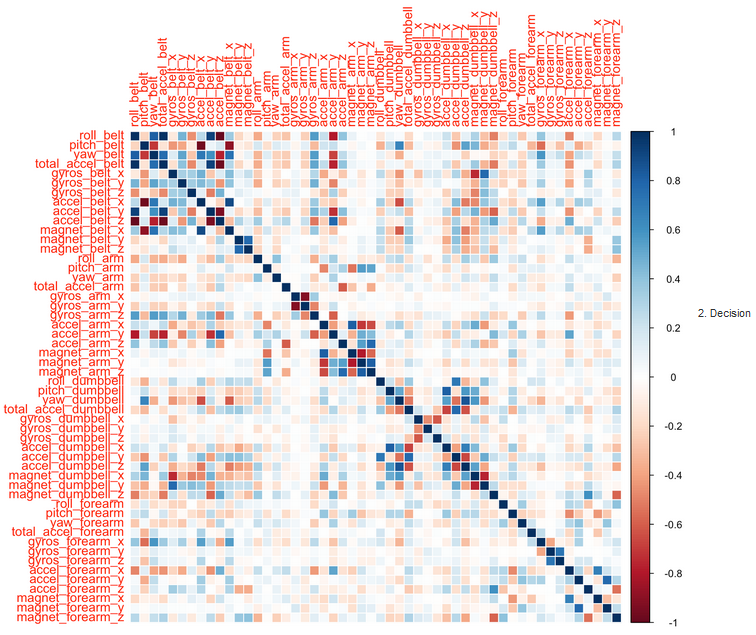

```r
removeCol <- grepl("classe", names(trainClean))
trainClean1 <- trainClean[, !removeCol]
M <- cor(trainClean1)
# library(corrplot) corrplot(M, method='circle')
```

**2) Tree diagram**

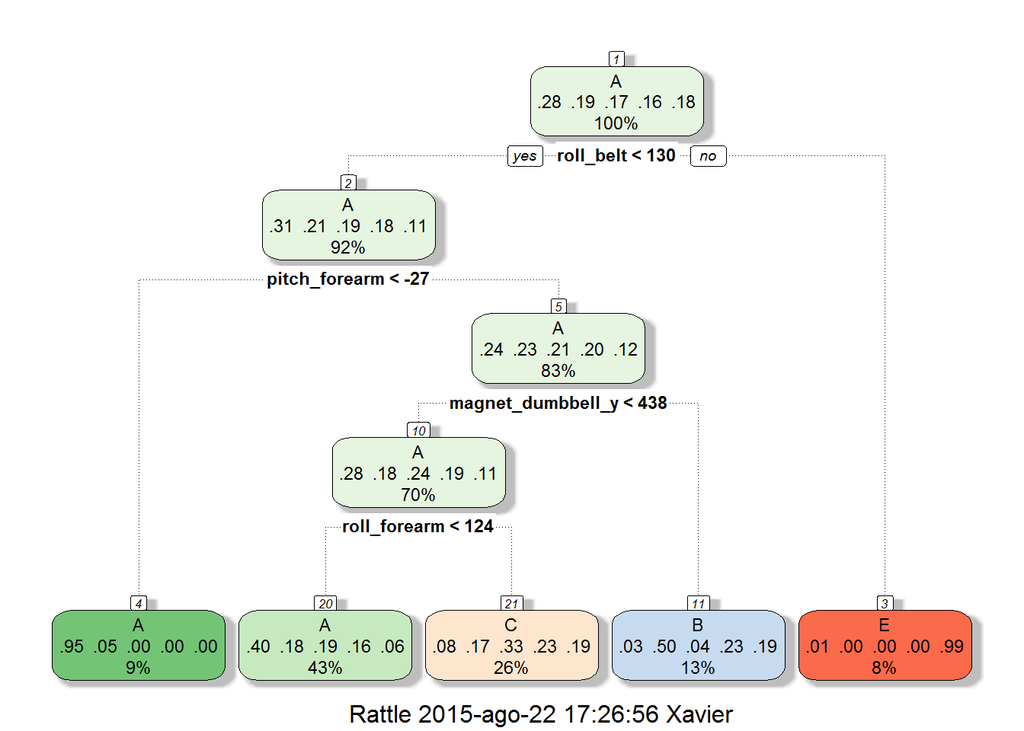

```r
library(rpart)
library(rattle)
treeModel <- train(classe ~ ., data = trainingSet, method = "rpart")
fancyRpartPlot(treeModel$finalModel)
```